# Agregador de Pesquisas - MacroCapital

João Pedro V. M. Leme

2022-05-24

## Agregador de Pesquisas Eleitorais

Este é um agregador simples de pesquisas de inteções de voto para os dois turnos das eleições presidenciais de 2022. A partir dos microdados disponibilizados pela database da Poder360, geraremos gráficos que modelam a evolução do percentual de votos de cada um dos candidatos especificados.

Cabe relembrar que o código aqui demonstrado é bastante flexível, já que outros filtros podem ser adicionados/acomodados com poucas mudanças, como a seleção de institutos de pesquisa em específico (ou mesmo a exclusão pontual de alguns deles), atribuição de pesos distintos para os resultados de determinadas pesquisas (usando critérios temporais ou institucionais, p. ex.), utilização de modelos econométricos distintos (nesse exercício, utilizamos LM e LOESS), ou mesmo sua reapropriação para outras eleições locais (governador, senador, etc.).

## Preliminares: Libraries utilizadas e conexão entre o DataLake e o Google Cloud

Utilizaremos aqui os microdados da Poder360, disponibilizados via BaseDosDados. Para isso, devemos instalar o pacote “basedosdados” e ativá-lo via função “library”. Em seguida, precisamos criar um projeto específico no Google Cloud e inserir seu ID no argumento da função “set_billing_id”. Por fim, basta fazer o download da base usando a função “bdplyr”.

```r
library("basedosdados")
library("tidyverse")
```

```r
library("ggplot2")

set_billing_id("agregadorpesquisas") #Substituir no argumento o ID do projeto no GoogleCloud
```

```
## Project keys set successfully
```

```r
query <- bdplyr("br_poder360_pesquisas.microdados")
```

[output not shown]

[output not shown]

[output not shown]

[output not shown]

```
## Successfully connected to table `basedosdados.br_poder360_pesquisas.microdados`.
```

## Criando dataframe com as informações relevantes

A partir dos microdados extraídos, podemos obter o dataframe geral utilizando a função “bd_collect”. Em seguida, selecionaremos as colunas/informações relevantes e construiremos um novo dataframe, que será utilizado para todas as demais operações.

```r
df <- bd_collect(query)

#Selecionando as colunas relevantes, temos:

df_2 <- data.frame(df$ano, df$cargo, df$data, df$data_referencia,
                   df$instituto, df$turno, df$descricao_cenario,
                   df$nome_candidato, df$percentual)

names(df_2) <- c("ano", "cargo", "data", "data_ref", "instituto", "turno",
                 "descricao_cenario", "candidato", "percentual")
```

## 1º Turno

A partir do novo dataframe, selecionaremos um subset que filtre as informações relevantes para o cenário eleitoral que se quer testar. No caso das eleições presidenciais de 2022, temos interesse no desempenho de *4 candidaturas (Lula, Jair Bolsonaro, Ciro Gomes e Simone Tebet)* em pesquisas de intenção de voto *estimuladas* feitas desde *1º de janeiro de 2021*.

```r
df_3 <- subset(df_2, ano >= 2022 & turno == 1 & cargo == "presidente" &
                     percentual >= 1 & (candidato %in% c("Bolsonaro" , "Lula",
                                                         "Ciro", "Simone Tebet")
                   | is.na(candidato)) & (descricao_cenario %in% c(
                        "cenário 2 - estimulado - 1º turno",
                     "cenário 2 - estimulada - 1º turno",
                     "cenário 3 - estimulada - 1º turno",
                     "cenário 4 - estimulada = 1º turno") |
                        is.na(descricao_cenario)) & data >= "2021-01-01")
```

Depois de selecionado o subset, podemos criar um novo dataframe sumarizando as informações relevantes para a construção dos gráficos (instituto responsável, data de publicação, candidato e percentual). Por fim, utilizaremos a função “as.Date” na coluna de data de publicação para evitar problemas no plot do gráfico.

```r
df_4 <- data.frame(df_3$instituto, df_3$data, df_3$candidato, df_3$percentual)

names(df_4) <- c("instituto", "data", "candidato", "percentual")

df_4$data <- as.Date(df_4$data)
```

## Criando os gráficos - 1º Turno - Modelo LOESS

```r
group.colors <- c("Lula" = "red", "Bolsonaro" = "blue", "Ciro" = "dark green",
                  "Simone Tebet" = "purple")

grafico_1turno <- ggplot(df_4, aes(x=data, y=percentual, colour=candidato)) +
                  geom_point() +
                  stat_smooth(data=subset(df_4,candidato == "Lula"), method = "loess",
                        size = 1, se = T, colour = "red") +
                  stat_smooth(data=subset(df_4,candidato == "Bolsonaro"), method = "loess",
                        size = 1, se = T, colour = "blue" ) +
                  stat_smooth(data=subset(df_4,candidato == "Ciro"), method = "loess",
                        size = 1, se = T, colour = "dark green") +
                  stat_smooth(data=subset(df_4,candidato == "Simone Tebet"), method = "loess",
                        size = 1, se = T, colour = "purple") +
                  scale_color_manual(values = group.colors)
```

Plotando, temos:

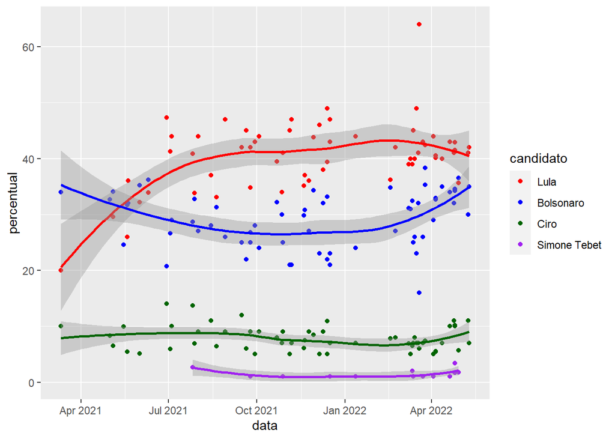

## Criando os gráficos - - 1º Turno - Modelo LM

```r
group.colors <- c("Lula" = "red", "Bolsonaro" = "blue", "Ciro" = "dark green", "Simone Tebet" = "purple")

grafico_1turno_b <- ggplot(df_4, aes(x=data, y=percentual, colour=candidato)) +
                    geom_point() +
                    stat_smooth(data=subset(df_4,candidato == "Lula"), method = "lm",
                        size = 1, se = T, colour = "red") +
                    stat_smooth(data=subset(df_4,candidato == "Bolsonaro"), method = "lm",
                        size = 1, se = T, colour = "blue" ) +
                    stat_smooth(data=subset(df_4,candidato == "Ciro"), method = "lm",
                        size = 1, se = T, colour = "dark green") +
                    stat_smooth(data=subset(df_4,candidato == "Simone Tebet"), method = "lm",
                        size = 1, se = T, colour = "purple") +
                    scale_color_manual(values = group.colors)
```

Plotando, temos:

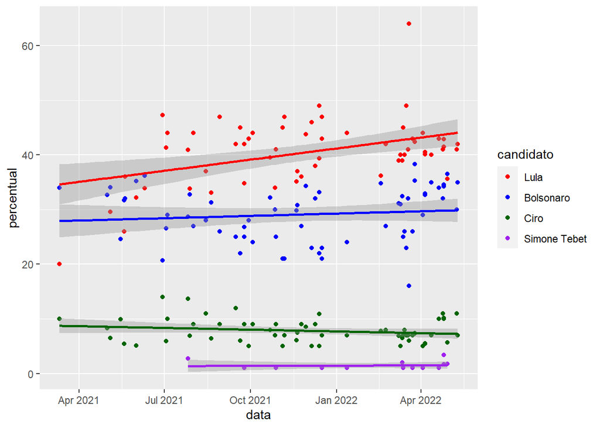

##2º Turno

Para o segundo turno, utilizaremos procedimento muito semelhante. A única diferença sensível é no corte do subset utilizado para gerar o dataframe final. Vejamos:

```r
df_5 <-  subset(df_2, ano >= 2022 & turno == 2 & cargo == "presidente" &
               percentual >= 1 & (candidato %in% c("Bolsonaro" , "Lula")
               | is.na(candidato)) & (descricao_cenario %in%
               c("cenário 1 - estimulado - 2º turno") |
               is.na(descricao_cenario)) & data >= "2021-01-01")
```

Selecionando o dataframe final:

```r
df_6 <- data.frame(df_5$instituto, df_5$data, df_5$candidato, df_5$percentual)

names(df_6) <- c("instituto", "data", "candidato", "percentual")

df_6$data <- as.Date(df_5$data)

head(df_6)
```

|  | instituto | data | candidato | percentual |
| --- | --- | --- | --- | --- |
| 1 | Ipespe | 2021-01-14 | Bolsonaro | 33 |
| 2 | Ipespe | 2021-01-14 | Bolsonaro | 33 |
| 3 | Ipespe | 2021-02-04 | Bolsonaro | 32 |
| 4 | Real Time Big Data | 2021-03-09 | Bolsonaro | 43 |
| 5 | Real Time Big Data | 2021-03-09 | Lula | 39 |
| 6 | Ideia Big Data | 2021-03-11 | Lula | 37 |

## Criando os gráficos - 2º Turno - Modelo LOESS

```r
group.colors2 <- c("Lula" = "red", "Bolsonaro" = "blue")

grafico_2turno <- ggplot(df_6, aes(x=data, y=percentual, colour=candidato)) +
                  geom_point()+
                  stat_smooth(data=subset(df_6, candidato == "Lula"), method = "loess",
                  size = 1, se = T, colour = "red") +
                  stat_smooth(data=subset(df_6, candidato == "Bolsonaro"), method = "loess",
                  size = 1, se = T , colour = "blue") +
                  scale_color_manual(values = group.colors2)
```

Plotando, temos:

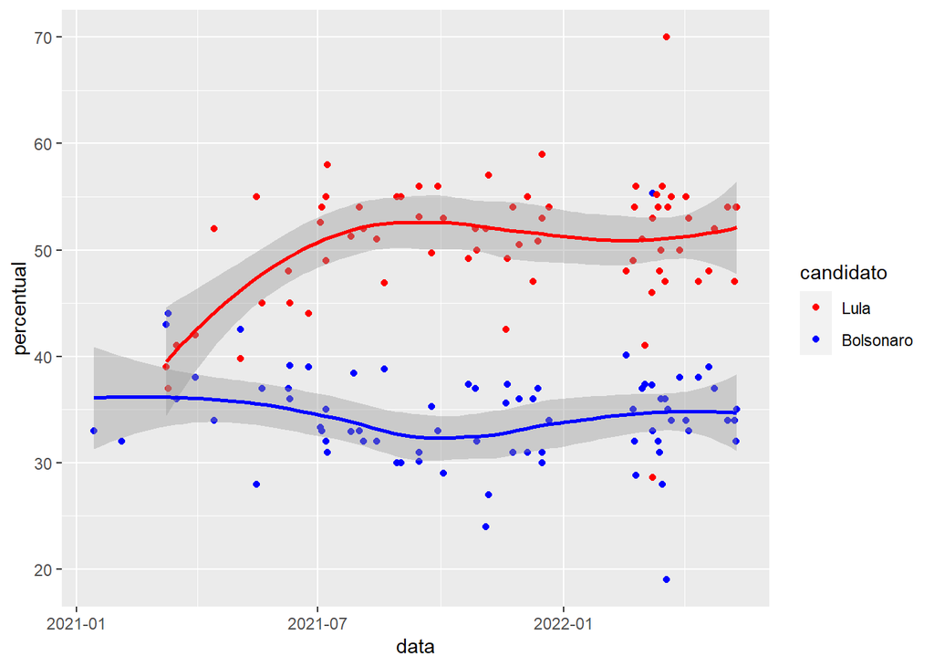

## Criando os gráficos - 2º Turno - Modelo LM

```r
group.colors2 <- c("Lula" = "red", "Bolsonaro" = "blue")

grafico_2turno_b <- ggplot(df_6, aes(x=data, y=percentual, colour=candidato)) +
                  geom_point()+
                  stat_smooth(data=subset(df_6, candidato == "Lula"), method = "lm",
                  size = 1, se = T, colour = "red") +
                  stat_smooth(data=subset(df_6, candidato == "Bolsonaro"), method = "lm",
                  size = 1, se = T , colour = "blue") +
                  scale_color_manual(values = group.colors2)
```

Plotando, temos:

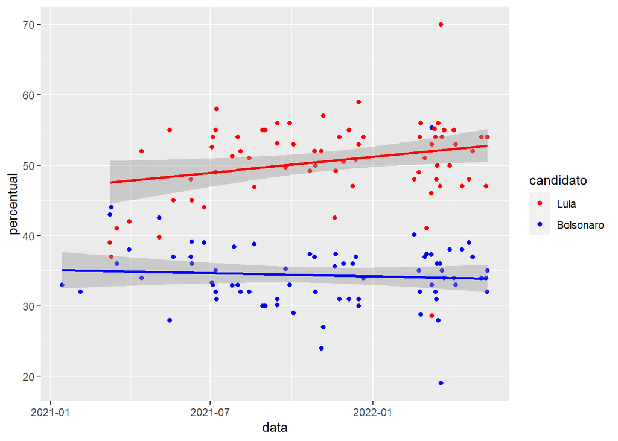